# Vernal pool mercury analysis

John D Lloyd

May 1, 2017

## Introduction

This document details a preliminary analysis of data collected on methylmercury levels in vernal pools in the Upper Valley.

## Data file summary

```r
data.df <- read.csv(url("https://raw.githubusercontent.com/5355693/VP_Mercury/master/hg_data.csv"))
summary(data.df)
```

```
##            Pool     Sample_Date   Spp       Amphib_MeHg
##  Downer      :32   5/12/15:28   SPSA: 96   Min.   :  0.8317
##  Mauran      :34   5/11/15:16   WOFR:100   1st Qu.:  5.2345
##  Podunk Conif:32   7/8/15 :14              Median : 43.1660
##  Podunk Decid:34   4/30/15:13              Mean   : 86.1619
##  Pomfret     :32   7/7/15 :13              3rd Qu.:118.4400
##  Shen        :32   (Other):79              Max.   :382.8120
##                    NA's   :33              NA's   :85
##    Amphib_THg             Life_Stage       Habitat       Water_Al
##  Min.   :  3.762   Adult       :52   Coniferous: 96   Min.   : 15.56
##  1st Qu.:  9.229   Early Larvae:48   Deciduous :100   1st Qu.: 24.26
##  Median :105.452   Eggs        :48                    Median : 41.00
##  Mean   :148.406   Late Larvae :48                    Mean   : 77.24
##  3rd Qu.:275.302                                      3rd Qu.:132.63
##  Max.   :561.799                                      Max.   :236.37
##  NA's   :85                                           NA's   :67
##     Water_S         Water_DOC        Water_pH       Water_MeHg
##  Min.   : 244.3   Min.   : 2695   Min.   :4.900   Min.   :0.00004
##  1st Qu.: 448.8   1st Qu.: 8838   1st Qu.:5.800   1st Qu.:0.00038
##  Median : 613.5   Median :13117   Median :6.000   Median :0.00081
##  Mean   : 671.8   Mean   :13845   Mean   :5.939   Mean   :0.00105
##  3rd Qu.: 796.0   3rd Qu.:15982   3rd Qu.:6.100   3rd Qu.:0.00182
##  Max.   :1305.5   Max.   :28371   Max.   :7.300   Max.   :0.00277
##  NA's   :67       NA's   :67      NA's   :67      NA's   :33
##   Season_MeHg       Tissue_MeHg       Blood_MeHg          S.V
##  Min.   :0.00022   Min.   : 13.30   Min.   : 11.26   Min.   : 44.00
##  1st Qu.:0.00041   1st Qu.: 29.82   1st Qu.: 26.50   1st Qu.: 47.75
##  Median :0.00055   Median : 43.07   Median : 50.90   Median : 53.50
##  Mean   :0.00080   Mean   : 63.49   Mean   : 49.82   Mean   : 65.62
##  3rd Qu.:0.00100   3rd Qu.: 85.07   3rd Qu.: 61.91   3rd Qu.: 85.00
##  Max.   :0.00195   Max.   :212.03   Max.   :147.79   Max.   :101.00
##  NA's   :121       NA's   :147      NA's   :161      NA's   :144
##    Tot_Length         Mass         Water_THg
##  Min.   :140.0   Min.   : 8.60   Min.   :0.00103
##  1st Qu.:162.2   1st Qu.:11.50   1st Qu.:0.00381
##  Median :170.0   Median :13.50   Median :0.00538
##  Mean   :171.3   Mean   :14.07   Mean   :0.00517
##  3rd Qu.:185.0   3rd Qu.:16.15   3rd Qu.:0.00634
##  Max.   :200.0   Max.   :23.70   Max.   :0.01025
##  NA's   :172     NA's   :145     NA's   :47
```

There are 6 pools, 3 of which are surrounded by deciduous forest (Downer, Mauran, and Podunk Decid) and 3 of which are surrounded by coniferous forest (Podunk Conif, Pomfret, and Shen). The number of samples differs by date and by pool because sample number is determined by the number of amphibians collected.

```
##               Sample_Date
## Pool           4/19/16 4/20/15 4/20/16 4/21/15 4/24/15 4/28/15 4/29/15
##   Downer             0       0       0       0       0       5       1
##   Mauran             0       4       0       3       0       3       0
##   Podunk Conif       0       0       0       0       0       0       0
##   Podunk Decid       2       0       0       0       1       0       0
##   Pomfret            0       0       0       0       0       0       4
##   Shen               0       0       2       0       0       0       0
##               Sample_Date
## Pool           4/30/15 5/1/15 5/11/15 5/12/15 5/13/15 5/18/15 5/2/16
##   Downer             0      0       0      10       0       0      0
##   Mauran             0      0       0       4       0       0      0
##   Podunk Conif       8      0       8       0       0       4      0
##   Podunk Decid       5      0       0      10       0       0      0
##   Pomfret            0      0       0       4       4       0      2
##   Shen               0      6       8       0       0       0      0
##               Sample_Date
## Pool           5/26/15 5/3/16 5/9/15 6/1/15 6/7/16 7/6/15 7/7/15 7/8/15
##   Downer             0      0      0      4      0      0      8      0
##   Mauran             0      0      8      4      0      8      0      0
##   Podunk Conif       0      0      0      0      0      0      0      6
##   Podunk Decid       0      0      0      0      0      0      0      8
##   Pomfret            0      2      0      0      4      0      5      0
##   Shen               4      0      0      0      0      4      0      0
```

## Exploratory analysis

### Methlymercury levels in water by pool, over time

Levels of methylmercury in water differ among pools and habitats and by time of sample. In general, coniferous pools have higher levels of methylmercury, but variation among pools is substantial. In addition, a seasonal trend is evident in pools surrounded by deciduous forest, but not among pools surrounded by coniferous forest.

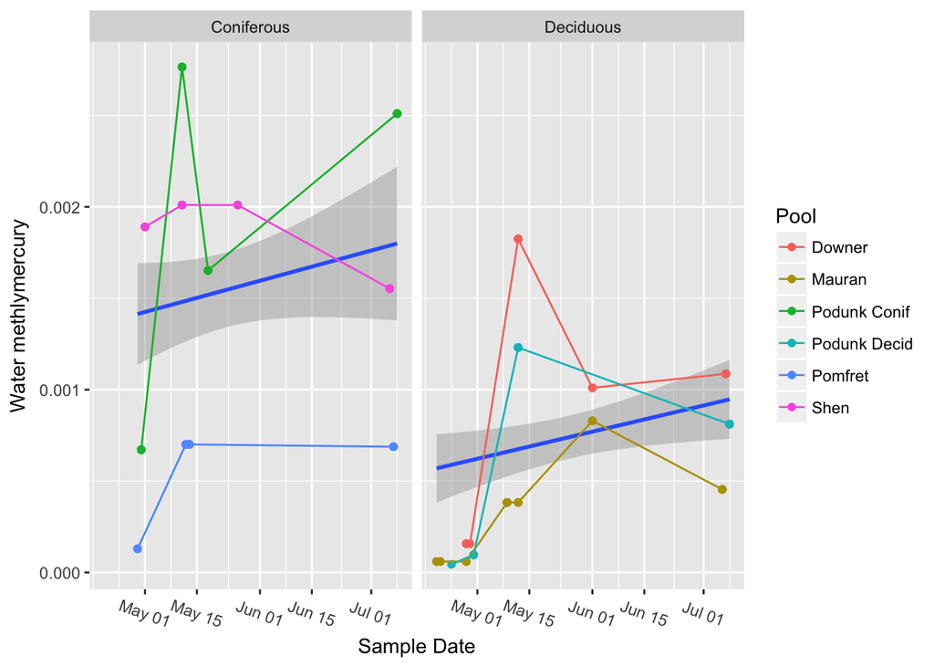

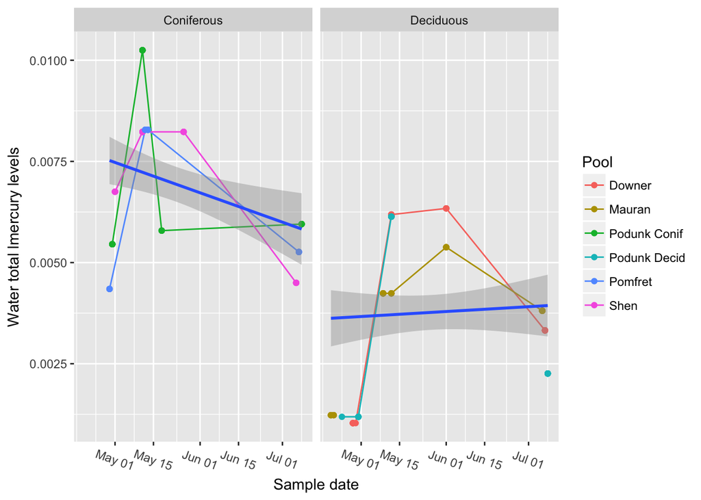

Performing a t-test assuming unequal variances, we find that the 95% credible interval for the difference in methylmercury (the parameter named “delta”) between the two habitats includes zero (0.000, 0.00146).

```
## Linked to JAGS 4.2.0
```

```
## Loaded modules: basemod,bugs
```

```
## module glm loaded
```

```
## Inference for Bugs model at "/var/folders/83/ltgpdkyd4js5ld5pnht4cjcw0000gn/T//RtmpuFqews/model153eb1d6412f4.txt", fit using jags,
##  3 chains, each with 5000 iterations (first 2500 discarded), n.thin = 2
##  n.sims = 3750 iterations saved
##             mu.vect sd.vect       2.5%        25%        50%        75%
## delta       0.00073 0.00037    0.00000    0.00048    0.00073    0.00096
## mu1         0.00067 0.00019    0.00028    0.00055    0.00067    0.00079
## mu2         0.00139 0.00031    0.00078    0.00119    0.00140    0.00159
## sigma1      0.00064 0.00016    0.00041    0.00053    0.00061    0.00072
## sigma2      0.00100 0.00027    0.00062    0.00082    0.00095    0.00113
## deviance -266.69224 3.51504 -271.09470 -269.30729 -267.44321 -264.96032
##               97.5%    Rhat n.eff
## delta       0.00146 1.00150  2200
## mu1         0.00104 1.00135  2700
## mu2         0.00202 1.00173  1800
## sigma1      0.00102 1.00135  3000
## sigma2      0.00167 1.00150  2200
## deviance -257.63514 1.00144  2400
##
## For each parameter, n.eff is a crude measure of effective sample size,
## and Rhat is the potential scale reduction factor (at convergence, Rhat=1).
##
## DIC info (using the rule, pD = var(deviance)/2)
## pD = 6.2 and DIC = -260.5
## DIC is an estimate of expected predictive error (lower deviance is better).
```

We can visualize this by showing a histogram of the posterior distribution of delta, with the 95% credible interval shown as vertical red lines.

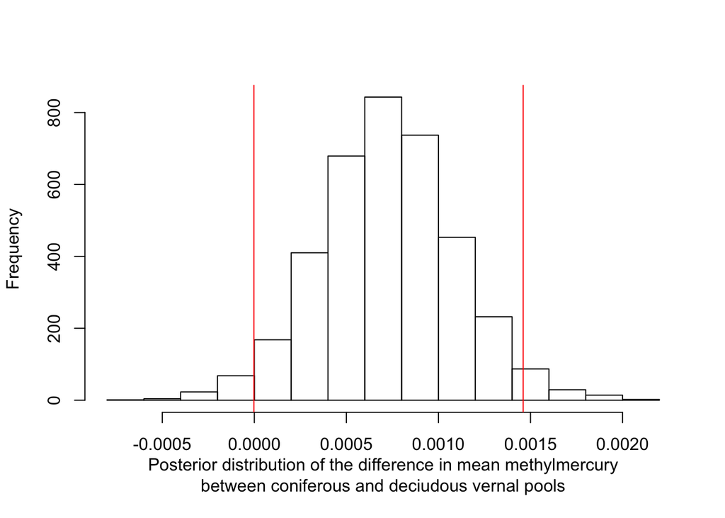

We can conclude that coniferous pools tend to have higher levels of methylmercury, but that the difference is not significant.

```
## Inference for Bugs model at "/var/folders/83/ltgpdkyd4js5ld5pnht4cjcw0000gn/T//RtmpuFqews/model153eb49313bce.txt", fit using jags,
##  3 chains, each with 50000 iterations (first 25000 discarded), n.thin = 25
##  n.sims = 3000 iterations saved
##             mu.vect sd.vect       2.5%        25%        50%        75%
## delta       0.00072 0.00037   -0.00004    0.00050    0.00072    0.00097
## mu1         0.00067 0.00019    0.00028    0.00054    0.00067    0.00079
## mu2         0.00139 0.00032    0.00072    0.00121    0.00139    0.00158
## sigma1      0.00064 0.00017    0.00041    0.00052    0.00061    0.00071
## sigma2      0.00099 0.00026    0.00062    0.00081    0.00094    0.00112
## deviance -266.73956 3.53277 -270.99724 -269.36634 -267.51113 -265.00652
##               97.5%    Rhat n.eff
## delta       0.00143 1.00243  1000
## mu1         0.00106 1.00054  3000
## mu2         0.00200 1.00276   890
## sigma1      0.00104 1.00152  2000
## sigma2      0.00165 1.00056  3000
## deviance -258.15889 1.00077  3000
##
## For each parameter, n.eff is a crude measure of effective sample size,
## and Rhat is the potential scale reduction factor (at convergence, Rhat=1).
##
## DIC info (using the rule, pD = var(deviance)/2)
## pD = 6.2 and DIC = -260.5
## DIC is an estimate of expected predictive error (lower deviance is better).
```

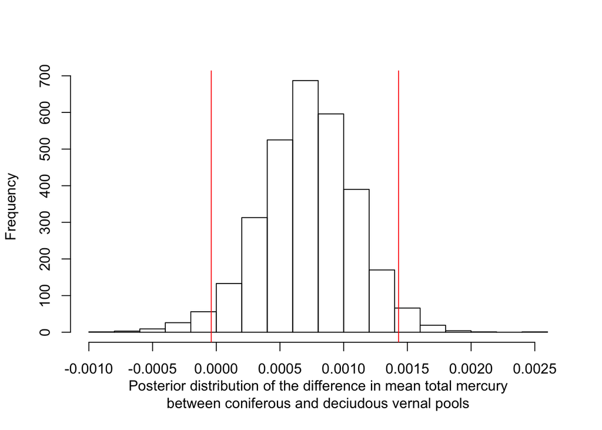

### Mercury levels in amphibians.

#### Adults

For adults, we need to choose which measure of mercury to use. More samples are missing blood mercury (n = 17) than are missing tissue mercury (n = 3). Therefore, for consistency, we should use tissue mercury as our measure.

```r
summary(data.df$Blood_MeHg[data.df$Life_Stage=="Adult"])
```

```
##    Min. 1st Qu.  Median    Mean 3rd Qu.    Max.    NA's
##   11.26   26.50   50.90   49.82   61.91  147.79      17
```

```r
summary(data.df$Tissue_MeHg[data.df$Life_Stage=="Adult"])
```

```
##    Min. 1st Qu.  Median    Mean 3rd Qu.    Max.    NA's
##   13.30   29.82   43.07   63.49   85.07  212.03       3
```

In addition, mercury levels measured in blood and tissue taken from the same individual show little correspondence and are not interchangeable. In this figure, mercury levels estimated from the same individual are connected by a line. Notice that tissue tends to be produce higher estimates of mercury load, but not always. Thus, mercury levels measured using the two different sample types aren’t comparable.

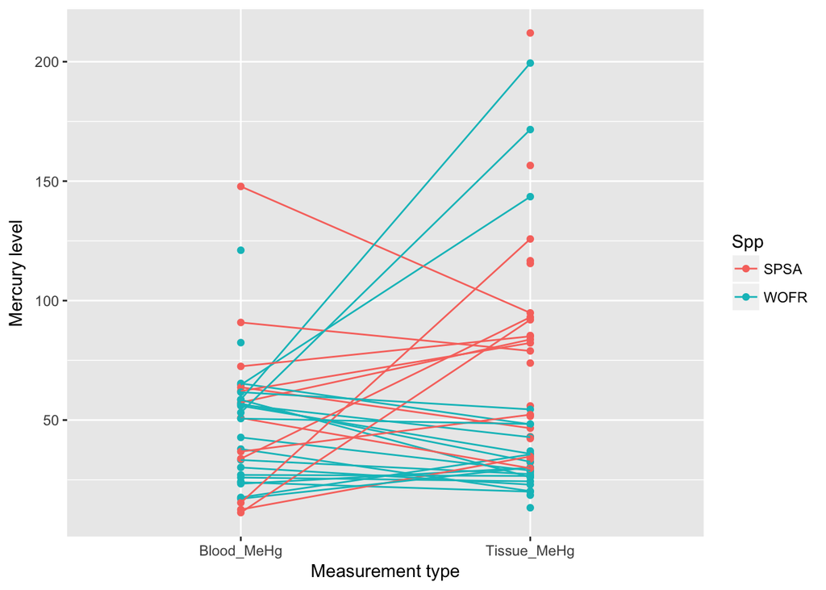

Patterns of tissue methylmercury vary among pools and species.

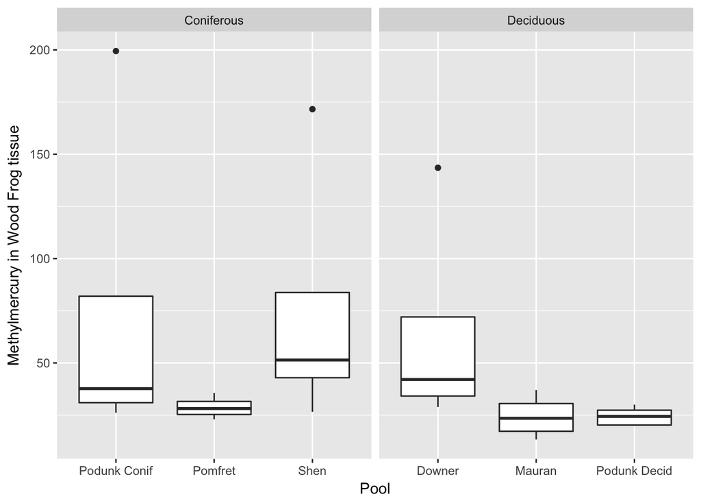

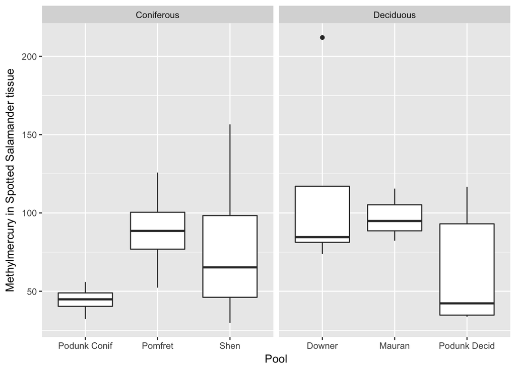

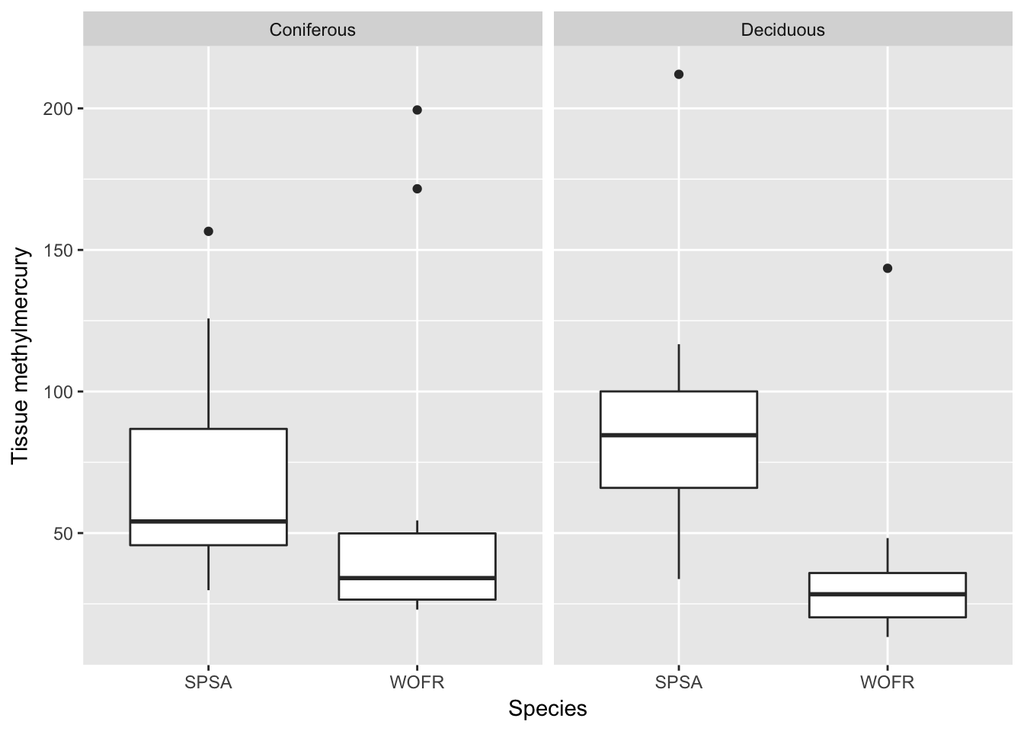

If we look at blood levels of methylmercury in adults:

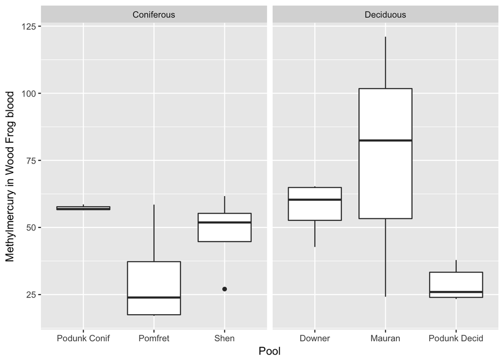

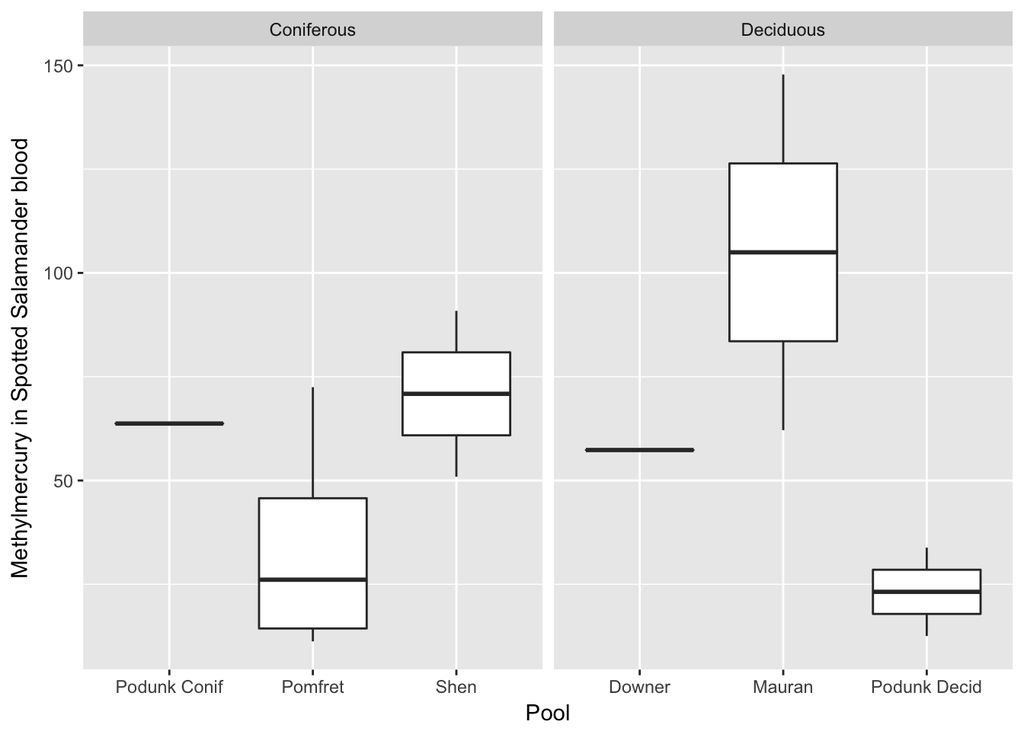

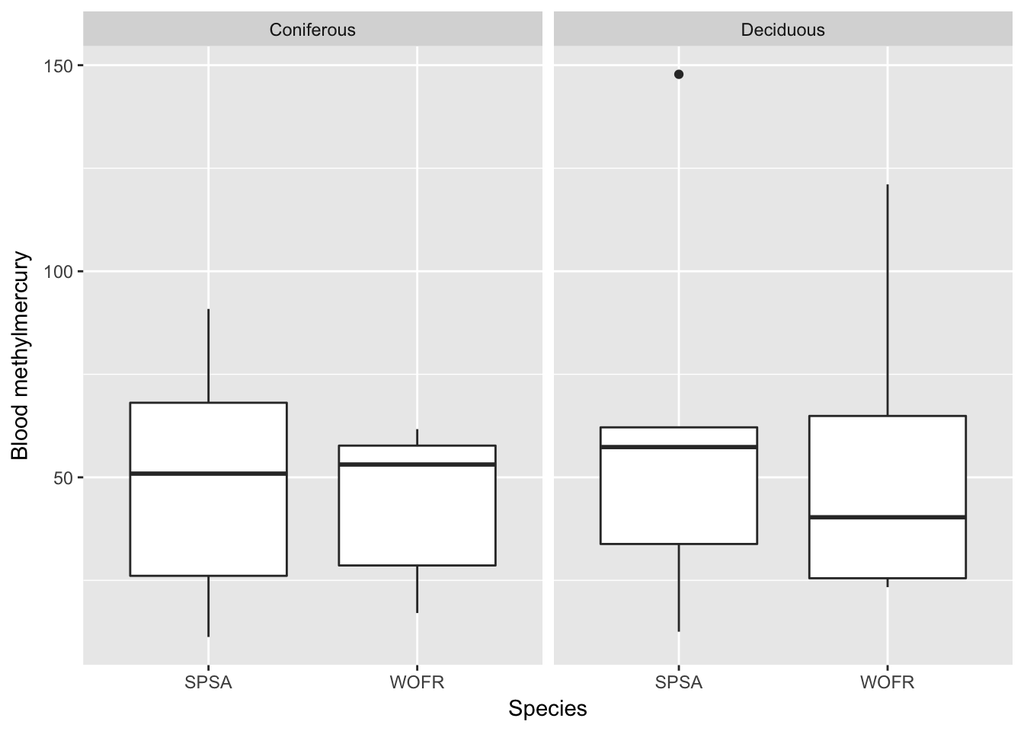

Neither species shows a strong relationship between levels of methylmercury in tissue and levels of methylmercury in the water at the time of the sample.

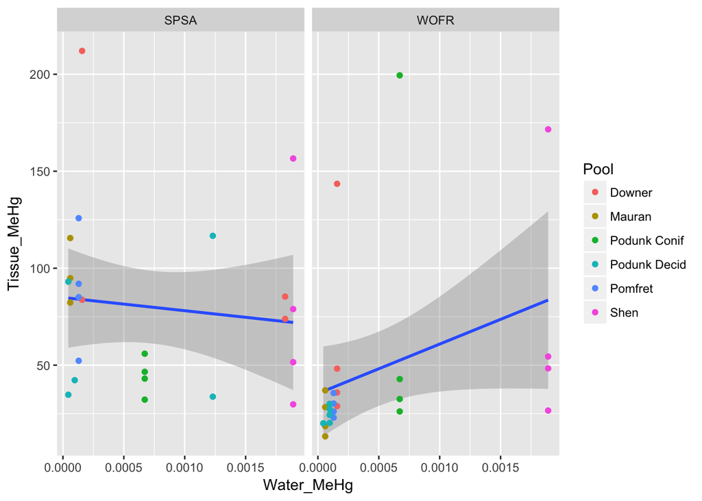

We see the same relationship if we look at blood methylmercury:

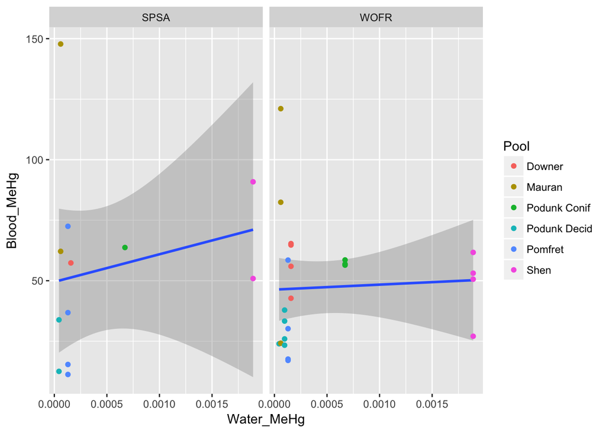

#### Larval stages

Unclear pattern of accumulation of mercury for juvenile stages. Eggs tend to have low values for both species. For Wood Frog, mercury levels accumulate as might be expected if tissue mercury depends on cumulative exposure to water mercury. In Spotted Salamanders, however, early larvae in deciduous pools tend to have higher levels than late larvae.

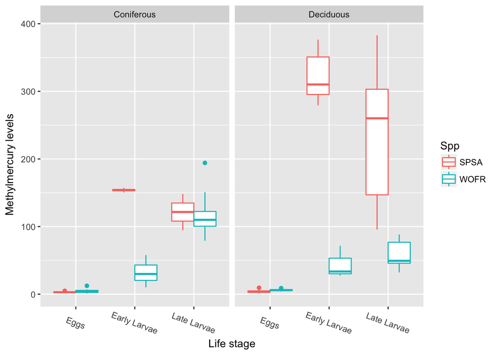

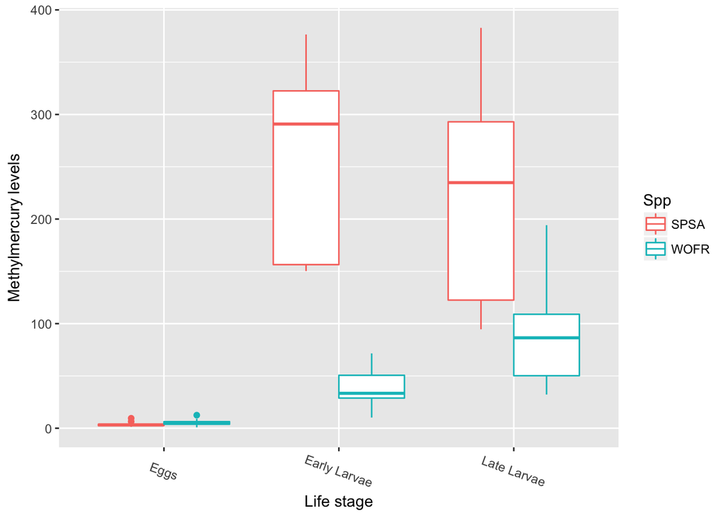

```r
p7 <- ggplot(data = subset(data.df, Life_Stage != "Adult"))
p7 + geom_boxplot(aes(x = Life_Stage, y = Amphib_MeHg, color = Spp)) +
  scale_x_discrete(limits = c("Eggs","Early Larvae","Late Larvae")) +
  theme(axis.text.x = element_text(angle = 340, vjust = 0.5)) +
  xlab("Life stage") + ylab("Methylmercury levels")
```

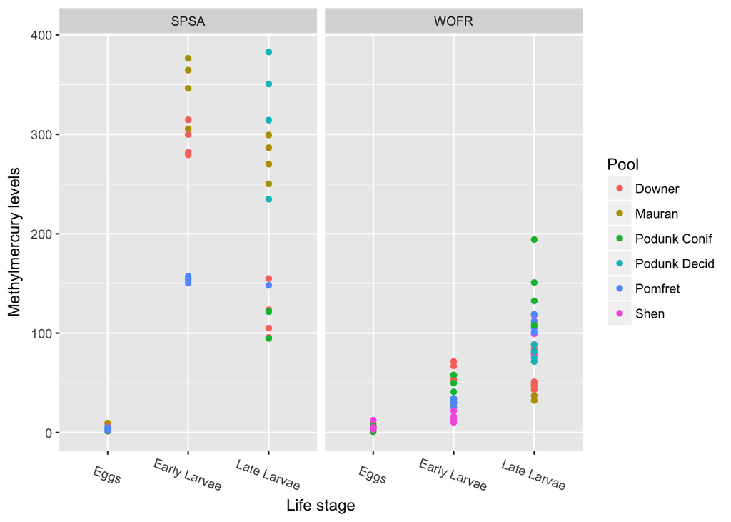

```r
p8 <- ggplot(data = subset(data.df, Life_Stage != "Adult"))
p8 + geom_point(aes(x = Life_Stage, y = Amphib_MeHg, color = Pool)) +
  scale_x_discrete(limits = c("Eggs","Early Larvae","Late Larvae")) +
  theme(axis.text.x = element_text(angle = 340, vjust = 0.5)) +
  xlab("Life stage") + ylab("Methylmercury levels") + facet_wrap(~Spp)
```

There is no consistent relationship between water mercury levels and levels of methylmercury in the tissue or blood of larval amphibians.

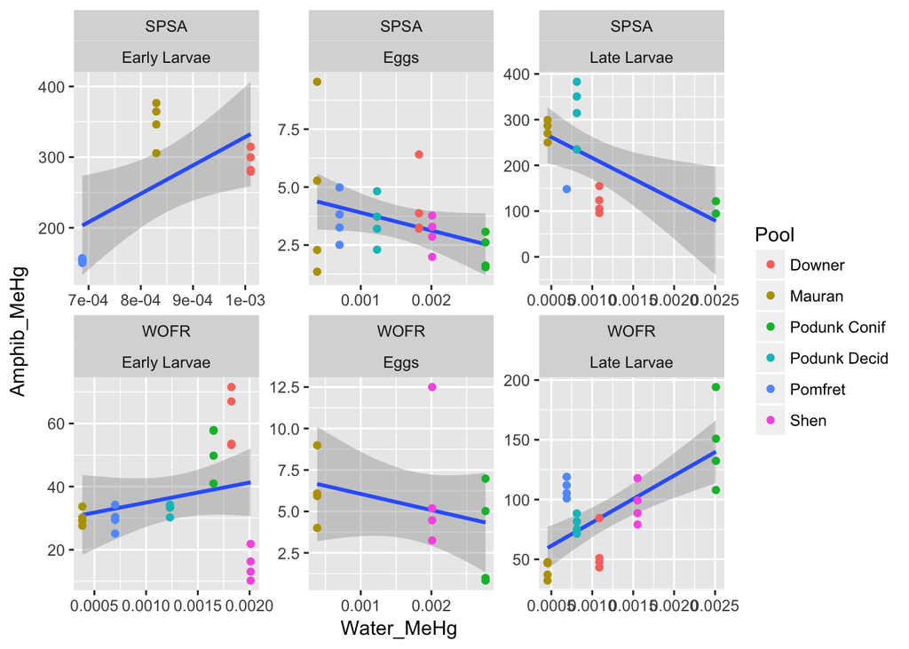

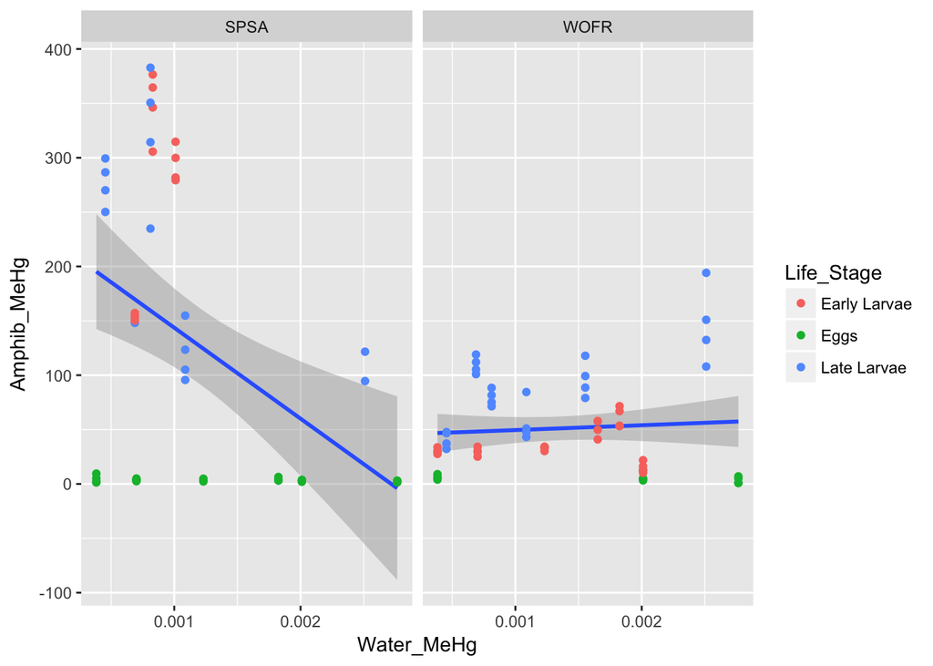

```r
p10 <- ggplot(data = subset(data.df, Life_Stage != "Adult"))
p10 + geom_smooth(aes(x = Water_MeHg, y = Amphib_MeHg), method = "lm") +
  geom_point(aes(x = Water_MeHg, y = Amphib_MeHg, color = Life_Stage)) + facet_wrap(~Spp)
```

## Formal analysis.

### Juvenile life stages.

For a more formal analysis, I compared 3 linear models within a Bayesian framework. For the juvenile life stages, these models included: 1. Amphibian mercury ~ species*water methlymercury. In this model, mercury level measured in amphibian larvae reflects an interaction between species and water mercury levels.

```
## Inference for Bugs model at "/var/folders/83/ltgpdkyd4js5ld5pnht4cjcw0000gn/T//RtmpuFqews/model153eb310fcf00.txt", fit using jags,
##  3 chains, each with 50000 iterations (first 25000 discarded), n.thin = 25
##  n.sims = 3000 iterations saved
##            mu.vect sd.vect      2.5%       25%       50%       75%
## alpha[1]  -6.12658 2.80635 -11.93649  -7.90748  -6.13713  -4.23789
## alpha[2]   2.39854 2.24151  -2.07557   0.92065   2.40264   3.87881
## beta[1]   -1.37860 0.40658  -2.21326  -1.63657  -1.37771  -1.10565
## beta[2]   -0.15374 0.32913  -0.80771  -0.36864  -0.15397   0.06465
## sigma      1.66330 0.11385   1.45914   1.58558   1.65798   1.73469
## deviance 426.53120 3.20556 422.38057 424.13509 425.81898 428.20450
##              97.5%    Rhat n.eff
## alpha[1]  -0.84947 1.00054  3000
## alpha[2]   6.77532 1.00101  3000
## beta[1]   -0.61664 1.00055  3000
## beta[2]    0.49598 1.00105  3000
## sigma      1.89383 1.00227  1100
## deviance 434.31172 1.00142  2200
##
## For each parameter, n.eff is a crude measure of effective sample size,
## and Rhat is the potential scale reduction factor (at convergence, Rhat=1).
##
## DIC info (using the rule, pD = var(deviance)/2)
## pD = 5.1 and DIC = 431.7
## DIC is an estimate of expected predictive error (lower deviance is better).
```

2. Amphibian mercury ~ species*water methlymercury + life stage. In this model, mercury level measured in amphibian larvae reflects an interaction between species and water mercury levels and an additive effect of life stage.

```r
spp <- data_subset2$Spp
hg <- log(data_subset2$Amphib_MeHg)
stage <- data_subset2$Life_Stage
stage <- droplevels(stage)
waterhg <- log(data_subset2$Water_MeHg) #could consider scaling this to get smaller Betas
n <- nrow(data_subset2)
n.groups <- length(levels(data_subset2$Spp))
n.stages <- 3
jags.params <- c("alpha","beta.spp", "beta.stage", "sigma")
jags.inits <- function(){
  list(sigma=rlnorm(1))
}
#Model
logmercuryanova2 <- function () {
  for(i in 1:n){
    hg[i] ~ dnorm(mu[i], tau)
    mu[i] <- alpha[spp[i]] + beta.spp[spp[i]]*waterhg[i] + beta.stage[stage[i]]
  }
  for(i in 1:n.groups){
    alpha[i] ~ dnorm(0, 0.001)
    beta.spp[i] ~ dnorm(0, 0.001)
  }
  for(i in 1:n.stages){
    beta.stage[i] ~ dnorm(0,0.001)
  }
  sigma ~ dunif(0,100)
  tau <- 1/(sigma*sigma)
}

jagsfitlogm2 <- jags(data = c("spp","hg","waterhg","n","n.groups","stage", "n.stages"), inits = jags.inits, jags.params,
                n.iter = 20000, model.file = logmercuryanova2)
print(jagsfitlogm2,digits = 5)
```

```
## Inference for Bugs model at "/var/folders/83/ltgpdkyd4js5ld5pnht4cjcw0000gn/T//RtmpuFqews/model153eb553bf5e5.txt", fit using jags,
##  3 chains, each with 20000 iterations (first 10000 discarded), n.thin = 10
##  n.sims = 3000 iterations saved
##                 mu.vect  sd.vect      2.5%       25%       50%       75%
## alpha[1]       -0.56305 14.21700 -26.89245 -10.40181  -1.09174   8.96276
## alpha[2]        2.60303 14.16376 -23.60369  -7.23834   2.09932  12.13684
## beta.spp[1]    -0.47541  0.16251  -0.79090  -0.58509  -0.47594  -0.36416
## beta.spp[2]     0.10763  0.13079  -0.13847   0.01891   0.10409   0.19739
## beta.stage[1]   1.98970 14.16999 -25.88954  -7.73932   2.65899  11.77417
## beta.stage[2]  -1.12333 14.17086 -28.82912 -10.82740  -0.49270   8.66749
## beta.stage[3]   2.49851 14.17146 -25.52409  -7.27704   3.15869  12.26252
## sigma           0.66272  0.04661   0.57913   0.63073   0.66006   0.69199
## deviance      221.66019  3.88310 216.17102 218.79067 221.02083 223.77544
##                   97.5%    Rhat n.eff
## alpha[1]       27.55091 1.00133  2400
## alpha[2]       30.27912 1.00126  2600
## beta.spp[1]    -0.14851 1.00136  3000
## beta.spp[2]     0.36796 1.00259   960
## beta.stage[1]  28.11009 1.00145  2100
## beta.stage[2]  24.84895 1.00144  2100
## beta.stage[3]  28.47932 1.00144  2100
## sigma           0.76176 1.00059  3000
## deviance      231.06567 1.00312   770
##
## For each parameter, n.eff is a crude measure of effective sample size,
## and Rhat is the potential scale reduction factor (at convergence, Rhat=1).
##
## DIC info (using the rule, pD = var(deviance)/2)
## pD = 7.5 and DIC = 229.2
## DIC is an estimate of expected predictive error (lower deviance is better).
```

3. Amphibian mercury ~ species*water methlymercury + life stage + habitat. In this model, mercury level measured in amphibian larvae reflects an interaction between species and water mercury levels and additive effects of life stage and habitat (deciduous vs coniferous).

```
## Inference for Bugs model at "/var/folders/83/ltgpdkyd4js5ld5pnht4cjcw0000gn/T//RtmpuFqews/model153eb3bcc84d0.txt", fit using jags,
##  3 chains, each with 20000 iterations (first 10000 discarded), n.thin = 10
##  n.sims = 3000 iterations saved
##                   mu.vect  sd.vect      2.5%       25%       50%       75%
## alpha[1]         -0.42142 17.81978 -35.52128 -12.62957  -0.22595  11.66861
## alpha[2]          2.90262 17.81155 -32.74519  -9.26945   3.08278  15.08491
## beta.habitat[1]   0.88993 17.72000 -34.02339 -10.83365   0.86773  12.47705
## beta.habitat[2]   1.04731 17.72273 -33.79250 -10.67686   1.02591  12.62670
## beta.spp[1]      -0.27654 18.02063 -34.52058 -12.37324  -0.18376  11.89924
## beta.spp[2]       0.32609 18.01809 -34.04821 -11.71364   0.40000  12.58073
## beta.stage[1]     1.16022 15.88069 -29.73635  -9.76855   1.11267  12.05213
## beta.stage[2]    -1.93497 15.87998 -33.04594 -12.89266  -1.93737   8.93739
## beta.stage[3]     1.66483 15.88078 -29.20827  -9.20547   1.61299  12.59277
## beta.waterhg     -0.15461 18.02008 -35.81625 -12.41003  -0.28548  11.96364
## bpvalue           0.51500  0.49986   0.00000   0.00000   1.00000   1.00000
## sigma             0.66085  0.04596   0.57741   0.62981   0.65925   0.68990
## deviance        221.50538  4.10373 215.38427 218.48367 220.83804 223.85088
##                     97.5%    Rhat n.eff
## alpha[1]         35.33457 1.00133  2400
## alpha[2]         38.30630 1.00137  2300
## beta.habitat[1]  35.07896 1.00155  1900
## beta.habitat[2]  35.22109 1.00156  1900
## beta.spp[1]      35.05908 1.00095  3000
## beta.spp[2]      36.02380 1.00095  3000
## beta.stage[1]    31.90006 1.00071  3000
## beta.stage[2]    28.78026 1.00071  3000
## beta.stage[3]    32.49144 1.00071  3000
## beta.waterhg     34.04239 1.00095  3000
## bpvalue           1.00000 1.00095  3000
## sigma             0.75700 1.00138  2300
## deviance        231.43661 1.00075  3000
##
## For each parameter, n.eff is a crude measure of effective sample size,
## and Rhat is the potential scale reduction factor (at convergence, Rhat=1).
##
## DIC info (using the rule, pD = var(deviance)/2)
## pD = 8.4 and DIC = 229.9
## DIC is an estimate of expected predictive error (lower deviance is better).
```

The best model is model 2 (it has the smallest Deviance Information Criterion (DIC), similar to AIC in that it reflects a balance between model fit and parsimony). In other words, mercury levels in larval amphibians depend on mercury levels in the water (although not in the expected way!) and on the life stage.

Adding an effect of habitat increases the DIC, indicating that this parameter is not useful in explaining variation in mercury levels in amphibians:

```r
cat(paste(c("DIC for Spp*WaterHg:"), jagsfitm1$BUGSoutput$DIC))
```

```
## DIC for Spp*WaterHg: 431.667697574029
```

```r
cat(paste(c("DIC for Spp*WaterHg + Stage"), jagsfitlogm2$BUGSoutput$DIC))
```

```
## DIC for Spp*WaterHg + Stage 229.184883257031
```

```r
cat(paste(c("DIC for Spp*WaterHg + Stage + Habitat:"),jagsfitlogm3$BUGSoutput$DIC))
```

```
## DIC for Spp*WaterHg + Stage + Habitat: 229.929067090714
```

Using that model for inference, we can generate predictions and figures that show the expected relationships.

Predictions for each life stage, from the best model:

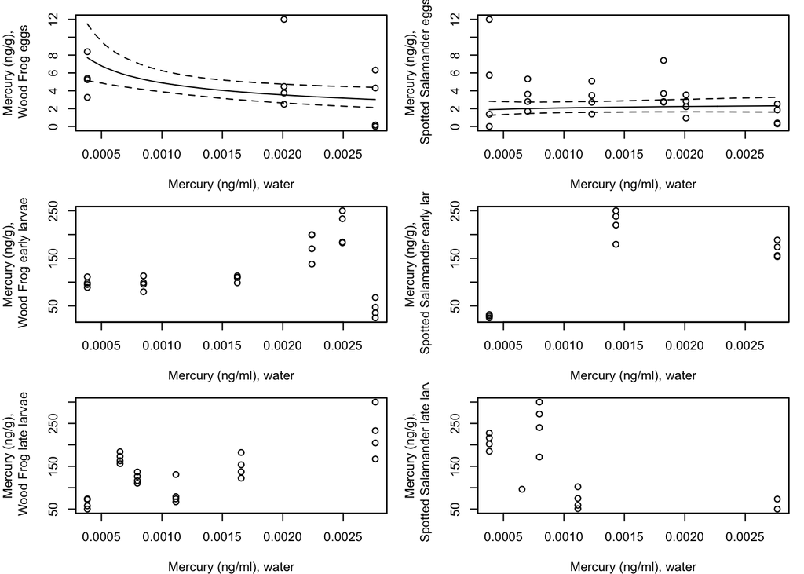

### Adults.

For adults, there are only 2 sensible models: 1) Tissue_MeHg ~ Species 2) Tissue_MeHg ~ Species + Habitat

I did not include any models with an effect of water mercury on tissue mercury because it is not biologically clear why this relationship should exist. Adults of both species are not resident within the pool, so I would not expect to find any effect of water mercury on the tissue mercury. Exploratory analyses support this assumption.

As with the juveniles, I analyzed both models in a Bayesian framework. First, the model that simply partitions variation among species:

```
## Inference for Bugs model at "/var/folders/83/ltgpdkyd4js5ld5pnht4cjcw0000gn/T//RtmpuFqews/model153eb4ad8d359.txt", fit using jags,
##  3 chains, each with 50000 iterations (first 25000 discarded), n.thin = 25
##  n.sims = 3000 iterations saved
##           mu.vect  sd.vect     2.5%      25%      50%      75%    97.5%
## alpha[1]  4.24504  0.12797  4.00338  4.15950  4.24658  4.32337  4.50364
## alpha[2]  3.59085  0.12435  3.34293  3.50829  3.59008  3.67614  3.83177
## delta    33.78761 10.21253 15.31855 26.89030 33.53968 40.15542 55.03394
## sigma     0.61955  0.06611  0.50399  0.57330  0.61504  0.65708  0.76339
## spsa     70.33442  9.09817 54.78299 64.03957 69.86636 75.44255 90.34561
## wofr     36.54680  4.57547 28.30196 33.39129 36.23680 39.49379 46.14407
## deviance 90.46918  2.63467 87.54111 88.54297 89.78061 91.65659 97.08799
##             Rhat n.eff
## alpha[1] 1.00066  3000
## alpha[2] 1.00094  3000
## delta    1.00052  3000
## sigma    1.00074  3000
## spsa     1.00067  3000
## wofr     1.00091  3000
## deviance 1.00075  3000
##
## For each parameter, n.eff is a crude measure of effective sample size,
## and Rhat is the potential scale reduction factor (at convergence, Rhat=1).
##
## DIC info (using the rule, pD = var(deviance)/2)
## pD = 3.5 and DIC = 93.9
## DIC is an estimate of expected predictive error (lower deviance is better).
```

Next, the model that includes an effect of habitat type:

```
## Inference for Bugs model at "/var/folders/83/ltgpdkyd4js5ld5pnht4cjcw0000gn/T//RtmpuFqews/model153eb5c3f802c.txt", fit using jags,
##  3 chains, each with 20000 iterations (first 10000 discarded), n.thin = 10
##  n.sims = 3000 iterations saved
##                  mu.vect sd.vect     2.5%      25%      50%      75%
## group.mean[1,1]  4.13220 0.17664  3.79133  4.01421  4.13194  4.24905
## group.mean[2,1]  3.79510 0.17698  3.43272  3.67753  3.79764  3.91604
## group.mean[1,2]  4.36424 0.17613  4.02386  4.24604  4.36425  4.47950
## group.mean[2,2]  3.39535 0.17098  3.05665  3.27783  3.39343  3.50971
## sigma            0.61026 0.06639  0.50172  0.56169  0.60388  0.65124
## deviance        88.85388 3.40506 84.45690 86.41542 88.15288 90.55366
##                    97.5%    Rhat n.eff
## group.mean[1,1]  4.47209 1.00075  3000
## group.mean[2,1]  4.14328 1.00131  2500
## group.mean[1,2]  4.71241 1.00088  3000
## group.mean[2,2]  3.72641 1.00096  3000
## sigma            0.76129 1.00112  3000
## deviance        97.11096 1.00141  2200
##
## For each parameter, n.eff is a crude measure of effective sample size,
## and Rhat is the potential scale reduction factor (at convergence, Rhat=1).
##
## DIC info (using the rule, pD = var(deviance)/2)
## pD = 5.8 and DIC = 94.6
## DIC is an estimate of expected predictive error (lower deviance is better).
```

Adding an effect of habitat does not improve the model fit, suggesting that habitat is not an important predictor of variation in mercury levels among adult amphibians.

```
## DIC, Model 1: 93.9413803248553
```

```
## DIC, Model 2: 94.6499606488611
```

The conclusion? Adult Wood Frogs have lower mercury levels than Spotted Salamanders, and habitat does not explain significant amounts of variation.

```
## Mean difference, Spotted Salamander - Wood Frog: 33.7876136557854
```

```
## 95% CI: 15.3185483740378 - 55.0339382413978
```

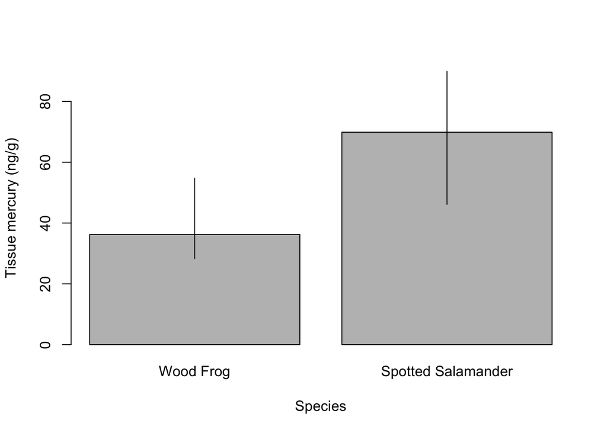

## Conclusion

Mercury levels - either methylmercury or total mercury - in the water of deciduous and coniferous vernal pools do not differ in this sample of pools. In part, the lack of variation probably reflects the rather small sample size.

For Spotted Salamanders, methylmercury loads tended to decrease as water methylmercury increased. For Wood Frogs, I found no relationship between methylmercury load and water methylmercury levels.

Among adults, tissue methylmercury varied among species. Spotted Salamanders had higher average loads than did Wood Frogs. Habitat did not explain variation in mercury loads among samples.

# Addendum

Steve asked that I consider 4 additional covariates of methylmercury: DOC, S, Al, and pH. I first examined whether adding any of these variables to the best model of methlymercury levels in the egg and larval amphibians.

The regression coefficient for water pH is not significantly different from zero, and including it doesn’t improve the model fit (the Deviance Information Criterion is higher).

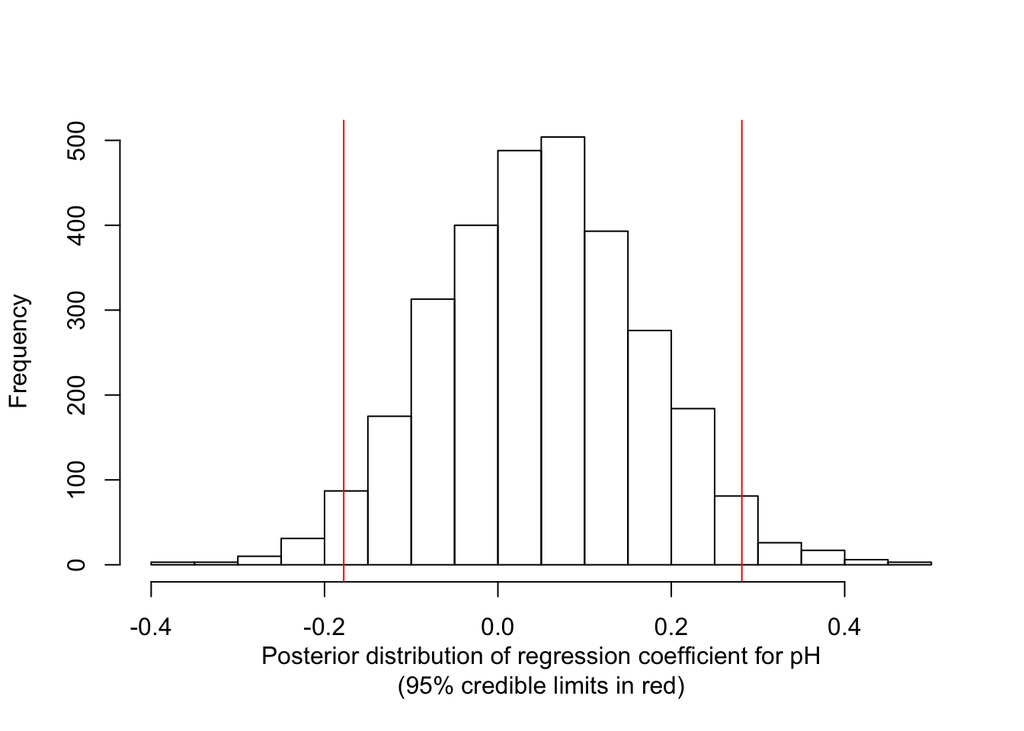

```
## DIC for Spp*WaterHg + Stage 229.184883257031
```

```
## DIC for Spp*WaterHg + Stage + pH: 231.465156112804
```

The same is true for Aluminum.

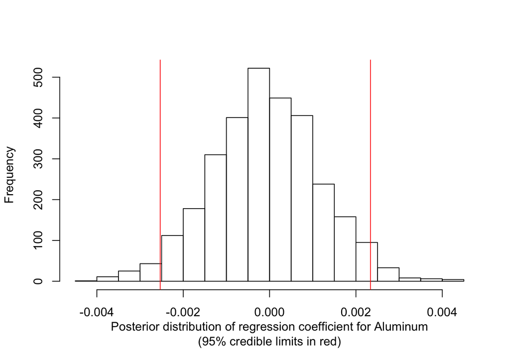

```
## DIC for Spp*WaterHg + Stage 229.184883257031
```

```
## DIC for Spp*WaterHg + Stage + Al: 231.0520577986
```

And DOC.

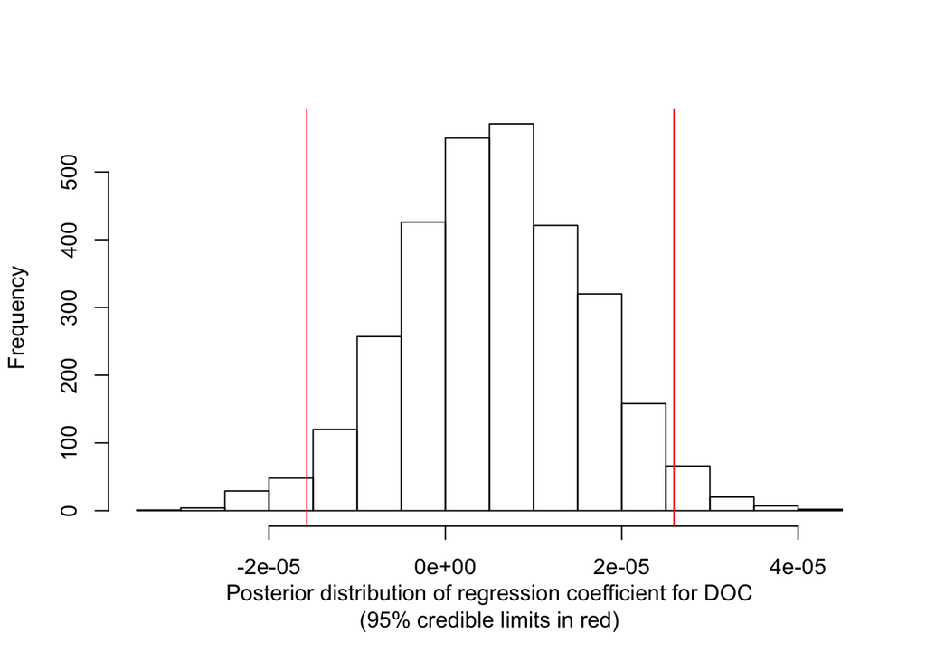

```
## DIC for Spp*WaterHg + Stage 229.184883257031
```

```
## DIC for Spp*WaterHg + Stage + DOC: 230.90269784412
```

And S.

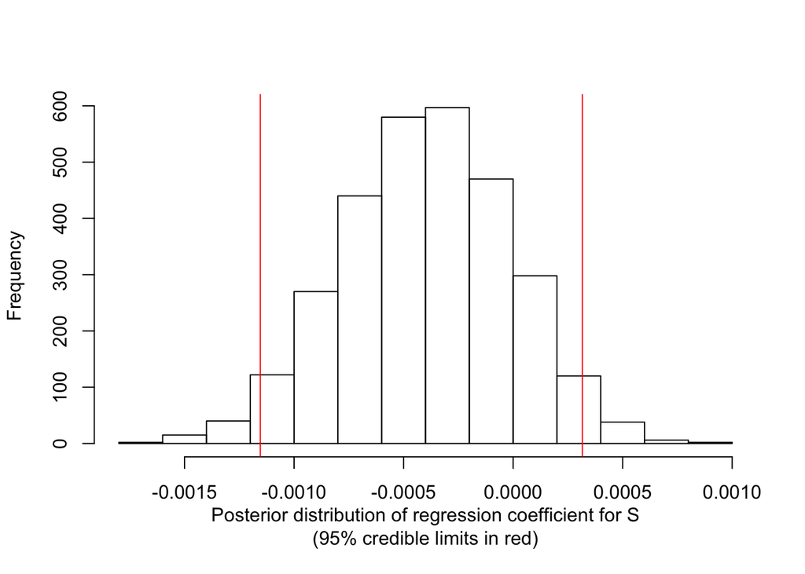

```
## DIC for Spp*WaterHg + Stage 229.184883257031
```

```
## DIC for Spp*WaterHg + Stage + S: 230.239975045208
```

Some of these variables do, however, show a relationship with water methylmercury. In particular, both water pH and water Aluminum are related to water methylmercury.

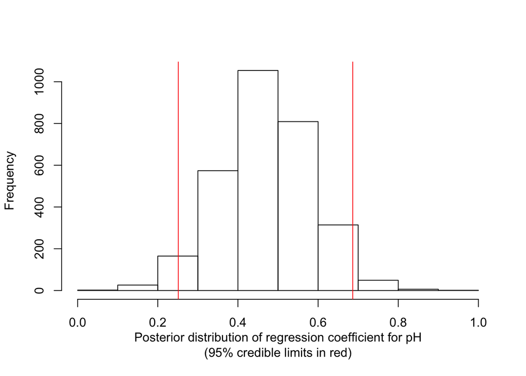

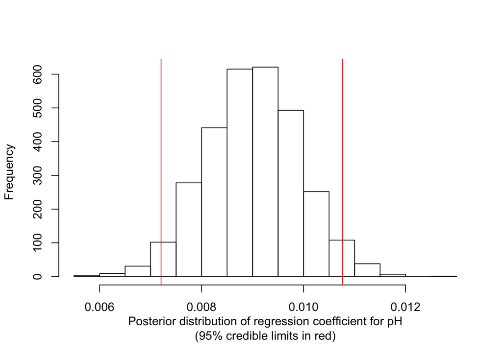

The predicted values suggest a positive relationship between methylmercury and pH, which is somewhat surprising. However, it appears that the relationship is driven by a single pool at Downer (observed points are shown as circles in these figures).

The relationship between water pH and water methylmercury (points are observed values, solid line is predicted relationship, and dashed lines are 95% credible limits):

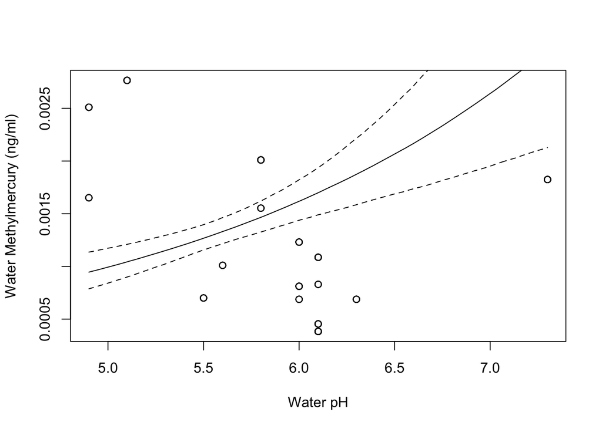

The relationship between water aluminum and water methylmercury (points are observed values, solid line is predicted relationship, and dashed lines are 95% credible limits):

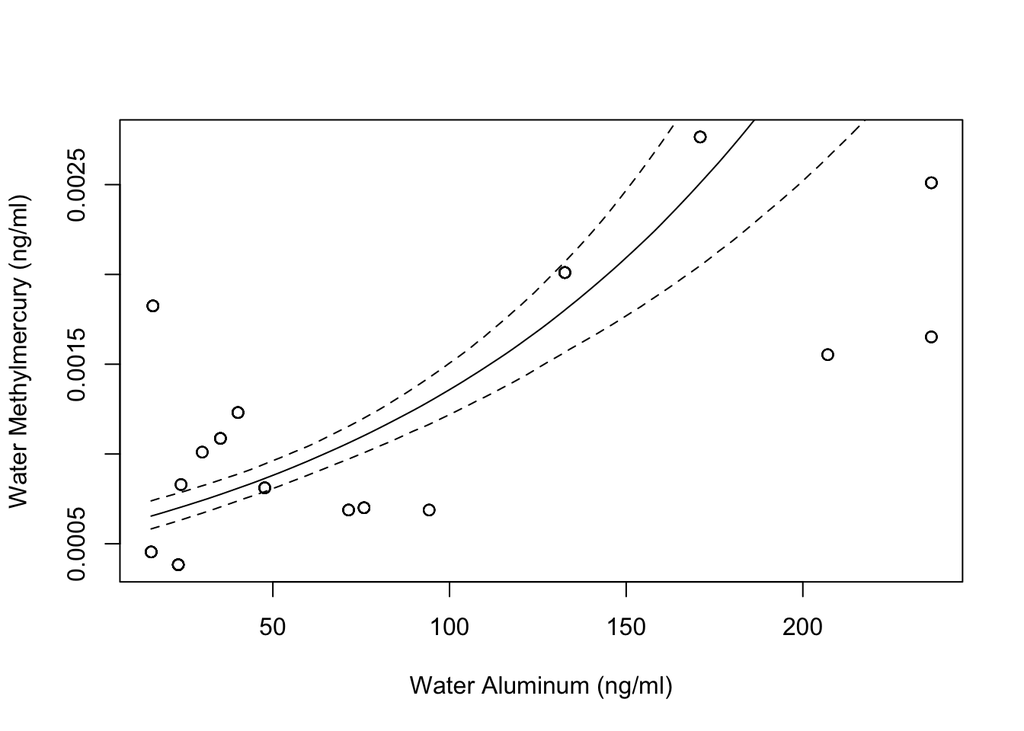